# Final Project

Kevin Russell

2024-04-30

```r
library(dplyr)
library(stringr)
library(udpipe)
library(tidyr)
library(lattice)
```

We’ll start by reading in the data from the first draft. There is some cleaning to be done– the quote character from the google doc doesn’t look like the quote character “. Additionally, we’ll have to insert a forward slash in front of those quotes, so that R doesn’t get confused.

```r
# Read the text file in, line by line
lines <- readLines("C:/Users/kruss/Downloads/Copy of Book 1 (text data).txt")
lines <- gsub("“|”", '"', lines)
lines <- gsub('"', '\"', lines)
```

Now we do the same for the second book.

```r
lines_two <- readLines("C:/Users/kruss/Downloads/Copy of Book Two (text data).txt")
lines_two <- gsub("“|”", '"', lines_two)
lines_two <- gsub('"', '\"', lines_two)
```

Let’s look at the lines we’ve parsed:

```r
lines[997:1000]
```

```
## [1] "        \"Stay there!\" said Quinn."
## [2] "        She walked up to Sadie, who still held the grip in her right hand. "
## [3] "        \"I want you to pull the string back like you were doing before.\""
## [4] "        She pulled it back."
```

```r
lines_two[997:1000]
```

```
## [1] "\"I was scared we were gonna lose you,\" said Valerie. "
## [2] "Quinn swallowed. "
## [3] "\"Yeah… this isn’t the night I was planning on having, you know.\""
## [4] "Valerie grinned from ear to ear. "
```

It seems like some of the lines have lots of spaces at the start– we can use gsub() and regular expressions to delete all spaces that start a line in both lines and lines_two.

```r
lines <- gsub("^\\s+", "", lines)

lines[997:1000]
```

```
## [1] "\"Stay there!\" said Quinn."
## [2] "She walked up to Sadie, who still held the grip in her right hand. "
## [3] "\"I want you to pull the string back like you were doing before.\""
## [4] "She pulled it back."
```

```r
lines_two <- gsub("^\\s+", "", lines_two)

lines_two[997:1000]
```

```
## [1] "\"I was scared we were gonna lose you,\" said Valerie. "
## [2] "Quinn swallowed. "
## [3] "\"Yeah… this isn’t the night I was planning on having, you know.\""
## [4] "Valerie grinned from ear to ear. "
```

Looks good. Now, let’s try grouping the paragraphs into sets of four. We can use a for loop, iterating through the list of lines by four.

```r
new_lines <- list()

for (i in seq(1, length(lines), by = 4)) {
  four_lines <- paste(lines[i:(i + 3)], collapse = " ")
  new_lines <- append(new_lines, list(four_lines))
}
```

```r
new_lines <- new_lines[1:821]
new_lines[775]
```

```
## [[1]]
## [1] "Shakily, he turned his hand over, offering the knife to someone else.  There were four other doctors in the room. Every one of them took a longing look at the weapon.  But before anyone had moved, a hole the size of a beach ball had appeared in the door, sending shrapnel flying into every pa…
```

```r
new_lines_two <- list()

for (i in seq(1, length(lines_two), by = 4)) {
  four_lines_two <- paste(lines_two[i:(i + 3)], collapse = " ")
  new_lines_two <- append(new_lines_two, list(four_lines_two))
}
```

```r
new_lines_two <- new_lines_two[1:468]
new_lines_two[400]
```

```
## [[1]]
## [1] "She had to smile, a little self-pitying smile. That wasn’t going to happen. She shook her head. \"Could you try writing it out?\" asked the doctor, retrieving a pen and pad from a drawer, as upbeat as ever. She took the pen and signed her name without thinking."
```

There is some substance to the entries in the new_lines and new_lines_two lists. Now, let’s throw them in dataframes, along with the draft number that they have come from.

```r
df_one <- data.frame(text = unlist(new_lines))

df_two <- data.frame(text = unlist(new_lines_two))
```

```r
df_one <- df_one |>
  mutate(draft_num = 1)

df_two <- df_two |>
  mutate(draft_num = 2)
```

```r
df<- rbind(df_one, df_two)

df <- df|>
    mutate(text_id = row_number())
```

And there we have it. There are 1,289 observations– 821 are from draft 1, and 468 are from draft 2. We’ll aim to build a model that predicts which text samples are from which draft.

Essentially, we’ll need to pull out important info from what we’ve been given.

First, let’s pull out the sentiments for each word using afinn. Each word in its dictionary gets a score, so we can sum up the scoring for each text row.

Source consulted: https://afit-r.github.io/sentiment_analysis

```r
library(tidytext)
get_sentiments("afinn")
```

```
## # A tibble: 2,477 × 2
##    word       value
##    <chr>      <dbl>
##  1 abandon       -2
##  2 abandoned     -2
##  3 abandons      -2
##  4 abducted      -2
##  5 abduction     -2
##  6 abductions    -2
##  7 abhor         -3
##  8 abhorred      -3
##  9 abhorrent     -3
## 10 abhors        -3
## # ℹ 2,467 more rows
```

We use unnest_tokens to pull out words and score them using afinn. Then, we use group_by to aggregate the scores for each entry.

```r
library(textdata)
sentiments <- df |>
  unnest_tokens(word, text) |>
  inner_join(get_sentiments("afinn"), by = "word") |>
  group_by(text_id, draft_num) |>
  summarise(sentiment = sum(value))
```

And now, we use a left join to restore the table, ensuring that text rows with no words in the dictionary get a sentiment score of 0, or neutral.

```r
df <- df |>
  left_join(sentiments, by = "text_id") |>
  mutate(sentiment = replace_na(sentiment, 0)) |>
  mutate(draft_num = draft_num.x) |>
  dplyr::select(c("text", "text_id", "draft_num", "sentiment"))
```

Now that we have sentiment scoring, we can calculate word length for each entry with regex finding matches for unique words.

```r
df <- df |>
  mutate(word_count = str_count(text, '\\w+'))
```

We can also add chapters to the dataframe, based on the fact that the sequence ‘./.’ marks the end of a chapter in the text column. We’ll use the cumsum() function to mark chapters, and then reset the count when draft two starts.

```r
df <- df |>
  mutate(chapter = cumsum(str_count(text, './\\.')) + 1) |>
  mutate(chapter = ifelse(draft_num == 2, chapter - 45, chapter))
```

POS extraction: Site referenced https://corpling.hypotheses.org/4081

We will pull out the proportion of each part of speech used in the documents that are the rows of the df.

```r
m_eng_ewt   <- udpipe_download_model(language = "english-ewt")
```

```
##  - This model has been trained on version 2.5 of data from https://universaldependencies.org
```

```
##  - The model is distributed under the CC-BY-SA-NC license: https://creativecommons.org/licenses/by-nc-sa/4.0
```

```
##  - Visit https://github.com/jwijffels/udpipe.models.ud.2.5 for model license details.
```

```
##  - For a list of all models and their licenses (most models you can download with this package have either a CC-BY-SA or a CC-BY-SA-NC license) read the documentation at ?udpipe_download_model. For building your own models: visit the documentation by typing vignette('udpipe-train', package = 'udp…
```

```r
m_eng_ewt_path <- m_eng_ewt$file_model
m_eng_ewt_loaded <- udpipe_load_model(file = m_eng_ewt_path)
```

We extract the parts of speech from each word using this code:

```r
pos_table <- udpipe_annotate(m_eng_ewt_loaded, x = df$text) |>
      as.data.frame() |>
      dplyr::select(-sentence)
```

Then we summarize the data and clean the columns so that they are of the format we want. We’ll look at the raw counts (n()) of each part-of-speech first. We’ll also perform a pivot_wider, so that the parts of speech are their own columns.

```r
pos_table_test <- pos_table |>
  group_by(doc_id, upos) |>
  summarise(count = n()) |>
  pivot_wider(names_from = upos, values_from = count, values_fill = 0) |>
  mutate(text_id = substring(doc_id, first = 4)) |>
  mutate(text_id = as.numeric(text_id))
```

We join the POS table with the existing df.

```r
df <- df |>
  left_join(pos_table_test, by="text_id")
```

And now, we take the proportion of the parts of speech.

```r
df <- df |>
  mutate(ADJ = ADJ/word_count) |>
  mutate(ADP = ADP/word_count) |>
  mutate(ADV = ADV/word_count) |>
  mutate(CCONJ = CCONJ/word_count) |>
  mutate(DET = DET/word_count) |>
  mutate(NOUN = NOUN/word_count) |>
  mutate(NUM = NUM/word_count) |>
  mutate(PART = PART/word_count) |>
  mutate(PRON = PRON/word_count) |>
  mutate(PROPN = PROPN/word_count) |>
  mutate(PUNCT = PUNCT/word_count) |>
  mutate(SCONJ = SCONJ/word_count) |>
  mutate(SYM = SYM/word_count) |>
  mutate(VERB = VERB/word_count) |>
  mutate(INTJ = INTJ/word_count) |>
  mutate(X = X/word_count) |>
  mutate(AUX = AUX/word_count)
```

```r
df <- df |>
  dplyr::select(-doc_id)
```

Topic Modeling: In this section, we will build a topic model that includes eight topics. We will then give each row eight new column, each representing the likelihood that the topic generated the document (between 0 and 1).

```r
library(topicmodels)
data("stop_words")
```

We’ll pull out our words from the text:

```r
df_tidy <- df |>
  unnest_tokens(word,
                text)
```

Then pull counts.

```r
df_counts <- df_tidy |>
  summarize(term_frequency = n(),
            .by = c(word, text_id)) |>
  arrange(desc(term_frequency))

df_counts |>
  head()
```

```
##   word text_id term_frequency
## 1    i     820             29
## 2  the    1058             27
## 3   to     820             25
## 4  she    1000             25
## 5  the    1076             25
## 6  the       3             23
```

And remove stop words.

```r
df_counts_clean <- df_counts |>
    anti_join(stop_words,
              by = join_by(word)) |>
  mutate(document = text_id) |>
  mutate(count = term_frequency) |>
  mutate(term = word) |>
  mutate(document = as.character(document)) |>
  mutate(count = as.double(count)) |>
  dplyr::select(document, count, term)

# Pull out characters that dominate the text or could clue the model in on what draft the passage is from
df_counts_clean <- df_counts_clean |>
  filter(!str_detect(term, "quinn|val|valerie|nicholas|steven"))

df_counts_clean |>
  head()
```

```
##   document count    term
## 1      593     9  leader
## 2      330     8   maeve
## 3      618     7   don’t
## 4      690     7 watched
## 5      869     7   actor
## 6     1038     7   don’t
```

Now we create our doc-term matrix for topic modeling.

```r
library("tidytext")

document_term_matrix <- df_counts_clean |>
  cast_dtm(document = document,
           term = term,
           value = count)

document_term_matrix
```

```
## <<DocumentTermMatrix (documents: 1289, terms: 8111)>>
## Non-/sparse entries: 39836/10415243
## Sparsity           : 100%
## Maximal term length: 27
## Weighting          : term frequency (tf)
```

Here we build the model with 8 topics.

```r
library(topicmodels)
library(MASS)
lda <- document_term_matrix |>
  LDA(k = 8,
      control = list(seed = 1))


save(lda, file = "lda.Rda")
```

And then visualize those topics.

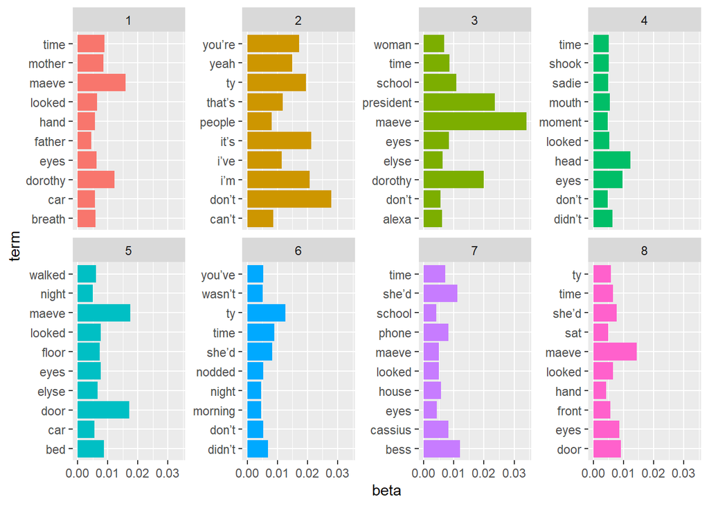

```r
library("ggplot2")
load("lda.Rda")
topics <- lda |>
  tidy(matrix = "beta")

top_terms <- topics |>
  group_by(topic) |>
  slice_max(beta, n = 10) |>
  mutate(topic = factor(topic))

top_terms |>
  ggplot(aes(beta,
             term,
             fill = topic)) +
  geom_col(show.legend = FALSE) +
  facet_wrap(~ topic,
             scales = "free_y",
             ncol = 4)
```

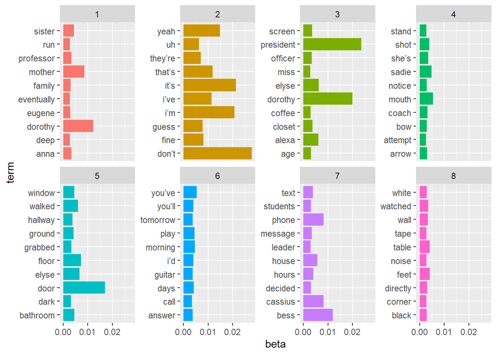

```r
top_terms_tf_idf <- topics |>
  filter(beta > 0.002) |>
    bind_tf_idf(term,
              topic,
              beta) |>
  group_by(topic) |>
  slice_max(tf_idf,
            n = 10) |>
  mutate(topic = factor(topic))

top_terms_tf_idf |>
  ggplot(aes(beta,
             term,
             fill = topic)) +
  geom_col(show.legend = FALSE) +
  facet_wrap(~ topic,
             scales = "free_y",
             ncol = 4)
```

Now, we pull out our topic probabilities.

```r
lda_memberships <- lda |>
  tidy(matrix = "gamma") |>
  mutate(text_id = as.integer(document)) |>
  dplyr::select(-document)

lda_memberships
```

```
## # A tibble: 10,312 × 3
##    topic    gamma text_id
##    <int>    <dbl>   <int>
##  1     1 0.000369     593
##  2     1 0.000579     330
##  3     1 0.000873     618
##  4     1 0.00104      690
##  5     1 0.997        869
##  6     1 0.000428    1038
##  7     1 0.000397     537
##  8     1 0.000465     866
##  9     1 0.000873    1037
## 10     1 0.000242    1076
## # ℹ 10,302 more rows
```

And that information is joined back into the df.

```r
df <- df |>
  left_join(lda_memberships, by = "text_id")
```

And we do some cleaning of the columns we have generated.

```r
df <- df |>
  pivot_wider(names_from = topic, values_from = gamma, values_fill = 0) |>
  mutate(topic_1 = `1`) |>
  mutate(topic_2 = `2`) |>
  mutate(topic_3 = `3`) |>
  mutate(topic_4 = `4`) |>
  mutate(topic_5 = `5`) |>
  mutate(topic_6 = `6`) |>
  mutate(topic_7 = `7`) |>
  mutate(topic_8 = `8`) |>
  dplyr::select(-c(`1`, `2`, `3`, `4`, `5`, `6`, `7`, `8`))
```

```r
df
```

```
## # A tibble: 1,289 × 31
##    text      text_id draft_num sentiment word_count chapter    ADJ    ADP    ADV
##    <chr>       <dbl>     <dbl>     <dbl>      <int>   <dbl>  <dbl>  <dbl>  <dbl>
##  1 "PART 1 …       1         1         3        196       1 0.0561 0.117  0.0612
##  2 "It was …       2         1        -3        226       1 0.0619 0.0973 0.106
##  3 "Of cour…       3         1        12        348       1 0.0661 0.101  0.0575
##  4 "The mor…       4         1        -4        144       1 0.0625 0.111  0.0417
##  5 "But bef…       5         1         9        238       1 0.0840 0.134  0.0378
##  6 "She had…       6         1         0        265       1 0.0717 0.136  0.0604
##  7 "The ear…       7         1        -3         96       1 0.0625 0.156  0.0625
##  8 "\"Do yo…       8         1        -2         64       1 0.0156 0.0781 0.0625
##  9 "The cro…       9         1         0         66       1 0.0303 0.0758 0.0758
## 10 "She had…      10         1         2        166       1 0.0542 0.139  0.0542
## # ℹ 1,279 more rows
## # ℹ 22 more variables: AUX <dbl>, CCONJ <dbl>, DET <dbl>, NOUN <dbl>,
## #   NUM <dbl>, PART <dbl>, PRON <dbl>, PROPN <dbl>, PUNCT <dbl>, SCONJ <dbl>,
## #   SYM <dbl>, VERB <dbl>, INTJ <dbl>, X <dbl>, topic_1 <dbl>, topic_2 <dbl>,
## #   topic_3 <dbl>, topic_4 <dbl>, topic_5 <dbl>, topic_6 <dbl>, topic_7 <dbl>,
## #   topic_8 <dbl>
```

At this point, we have sentiment scoring, part of speech proportion, and LDA topic probabilities from our text data. We have extracted this numerical information from the data so that our models might be able to classify the text into its correct draft. Let’s get a preliminary look at our data.

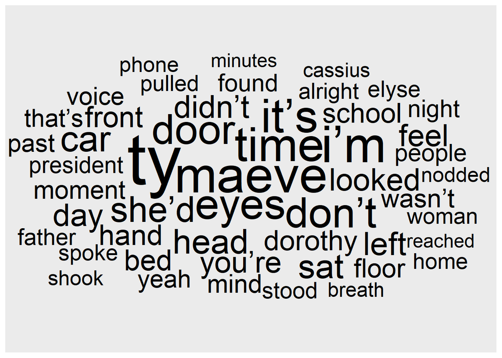

```r
# Overall word cloud (Quinn is excluded)

library(ggwordcloud)
df_counts_clean |>
  group_by(term) |>
  summarize(term_frequency = sum(count)) |>
  slice_max(term_frequency,
            n = 50) |>
  ggplot() +
  geom_text_wordcloud_area(aes(label = term,
                               size = term_frequency)) +
  scale_size_area(max_size = 40)
```

We can also make a word cloud for the first chapter of the first draft:

```r
df_counts_chapter <- df_tidy |>
  summarize(term_frequency = n(),
            .by = c(word, chapter, draft_num)) |>
  arrange(desc(term_frequency))

df_counts_chapter |>
  head()
```

```
##   word chapter draft_num term_frequency
## 1  the      12         2            416
## 2  the      11         1            250
## 3  the       3         2            227
## 4  the       7         1            225
## 5  the       6         2            217
## 6  the      16         1            205
```

```r
df_counts_clean_chapter <- df_counts_chapter |>
    anti_join(stop_words,
              by = join_by(word))

df_counts_clean_chapter |>
  head()
```

```
##      word chapter draft_num term_frequency
## 1   quinn      12         2            118
## 2   maeve      16         1             67
## 3   quinn       6         2             65
## 4 valerie      12         2             63
## 5   quinn      11         1             55
## 6    bess      37         1             53
```

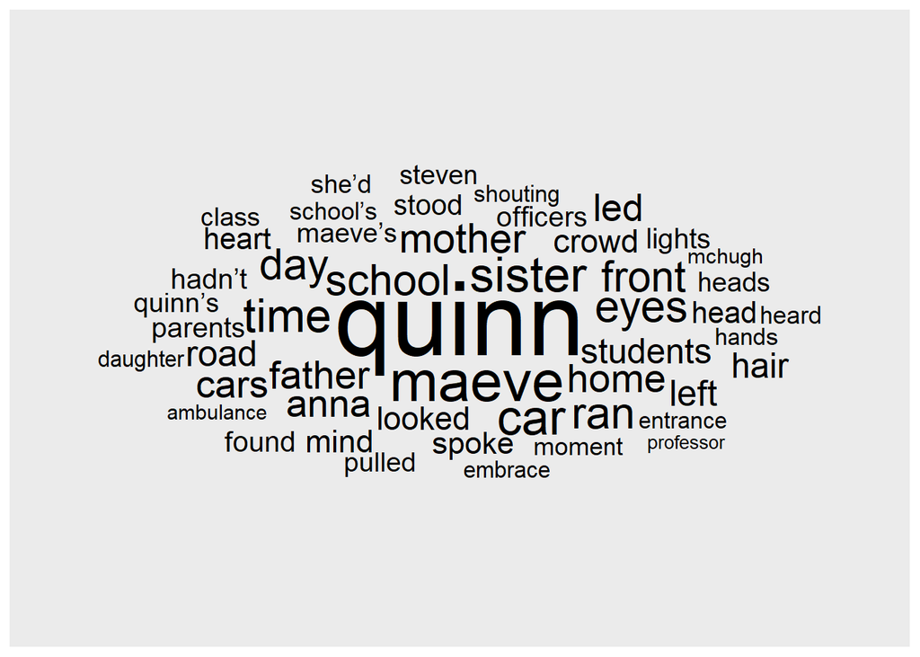

```r
df_counts_clean_chapter |>
  filter(chapter == 1) |>
  filter(draft_num == 1) |>
  slice_max(term_frequency,
            n = 50, with_ties = FALSE)  |>
  ggplot() +
  geom_text_wordcloud_area(aes(label = word,
                               size = term_frequency)) +
  scale_size_area(max_size = 40)
```

We can also plot average document length by chapter. Each entry represents the average paragraph length in words of the chapter.

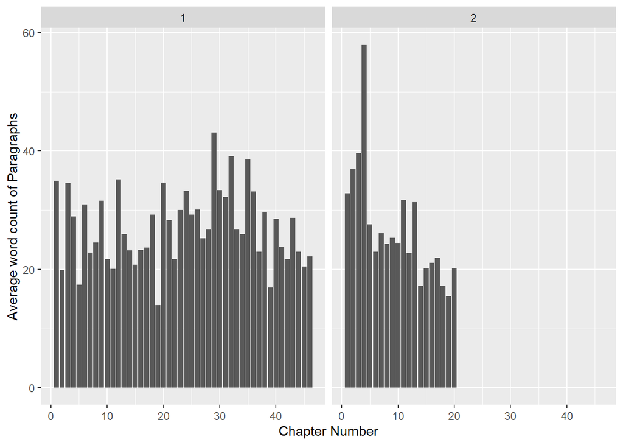

```r
df |>
  group_by(draft_num, chapter) |>
  summarise(avg_word_count = mean(word_count)) |>
  mutate(avg_word_count = avg_word_count/4) |>
    ggplot(aes(x = chapter, y = avg_word_count)) +
  geom_bar(stat = "identity") +
  facet_wrap(~ draft_num) +
  labs(x = "Chapter Number", y = "Average word count of Paragraphs")
```

Though the first few chapters of draft 2 seem visually to have longer paragraphs than those in draft 1, it doesn’t seem readily apparent that the paragrah lengths are different between the books.

Now, let’s look at how the average topic scores evolve over the course of the novel:

```r
df_topics <- df |>
  group_by(draft_num, chapter) |>
  summarise(topic_1 = mean(topic_1), topic_2 = mean(topic_2), topic_3 = mean(topic_3),
            topic_4 = mean(topic_4), topic_5 = mean(topic_5), topic_6 = mean(topic_6),
            topic_7 = mean(topic_7), topic_8 = mean(topic_8))
df_topics
```

```
## # A tibble: 66 × 10
## # Groups:   draft_num [2]
##    draft_num chapter topic_1 topic_2 topic_3 topic_4 topic_5 topic_6 topic_7
##        <dbl>   <dbl>   <dbl>   <dbl>   <dbl>   <dbl>   <dbl>   <dbl>   <dbl>
##  1         1       1 0.415    0.0470 0.0615  0.0914  0.0656  0.00115 0.246
##  2         1       2 0.136    0.268  0.0155  0.105   0.154   0.180   0.0887
##  3         1       3 0.254    0.0673 0.0340  0.0585  0.155   0.246   0.119
##  4         1       4 0.153    0.0721 0.0399  0.104   0.0688  0.168   0.274
##  5         1       5 0.0970   0.322  0.00200 0.0305  0.149   0.221   0.0982
##  6         1       6 0.00102  0.233  0.00102 0.265   0.147   0.0674  0.00102
##  7         1       7 0.0830   0.223  0.0978  0.136   0.148   0.180   0.0364
##  8         1       8 0.00150  0.349  0.0983  0.0883  0.111   0.108   0.00150
##  9         1       9 0.213    0.127  0.0635  0.422   0.00112 0.0195  0.0163
## 10         1      10 0.00150  0.688  0.00150 0.00150 0.262   0.0423  0.00150
## # ℹ 56 more rows
## # ℹ 1 more variable: topic_8 <dbl>
```

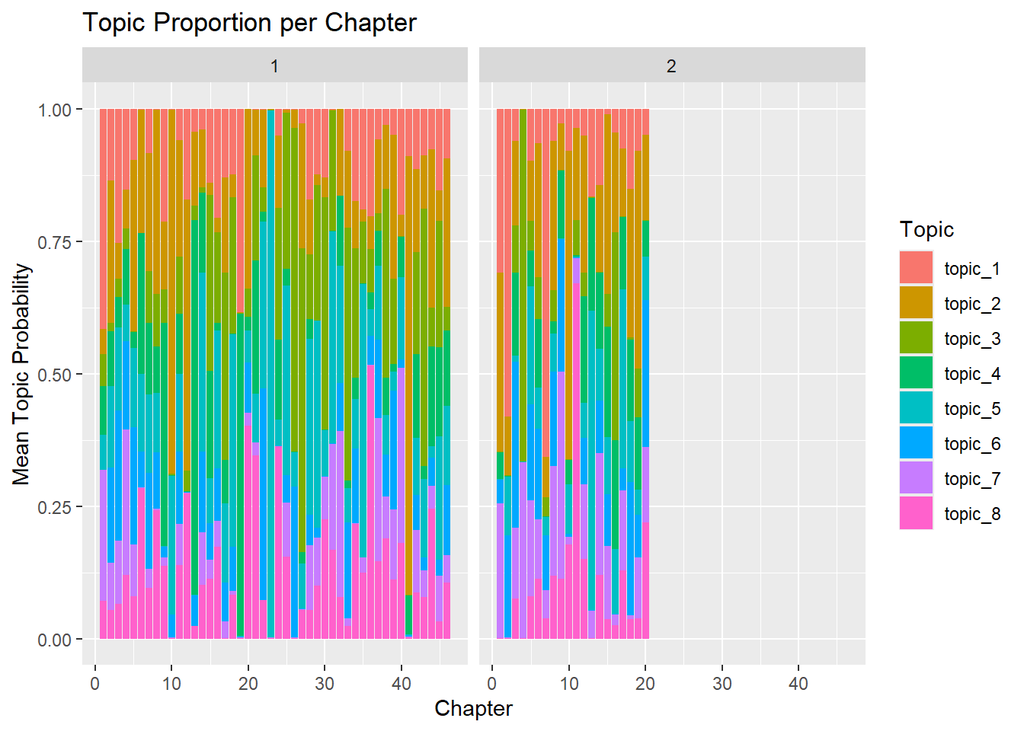

```r
df_topics |>
  pivot_longer(cols = starts_with("topic"), names_to = "topic", values_to = "value") |>
  ggplot(aes(x = chapter, y = value, fill = topic)) +
  geom_bar(stat = "identity", position = "stack") +
  facet_wrap(~ draft_num) +
  labs(x = "Chapter", y = "Mean Topic Probability", title = "Topic Proportion per Chapter", fill = "Topic")
```

Topics 1 and 3 are more common in draft 1, while topics 2 and perhaps 7 seem more common in draft 2.

We can track proportion of noun, verb, and adjective use as well:

```r
df_pos <- df |>
  group_by(draft_num, chapter) |>
  summarise(nouns = mean(NOUN), verbs = mean(VERB), adjectives = mean(ADJ))
df_pos
```

```
## # A tibble: 66 × 5
## # Groups:   draft_num [2]
##    draft_num chapter nouns verbs adjectives
##        <dbl>   <dbl> <dbl> <dbl>      <dbl>
##  1         1       1 0.194 0.155     0.0471
##  2         1       2 0.175 0.184     0.0673
##  3         1       3 0.166 0.169     0.0460
##  4         1       4 0.176 0.149     0.0504
##  5         1       5 0.148 0.180     0.0597
##  6         1       6 0.192 0.151     0.0628
##  7         1       7 0.150 0.160     0.0601
##  8         1       8 0.145 0.159     0.0565
##  9         1       9 0.170 0.151     0.0576
## 10         1      10 0.115 0.171     0.0623
## # ℹ 56 more rows
```

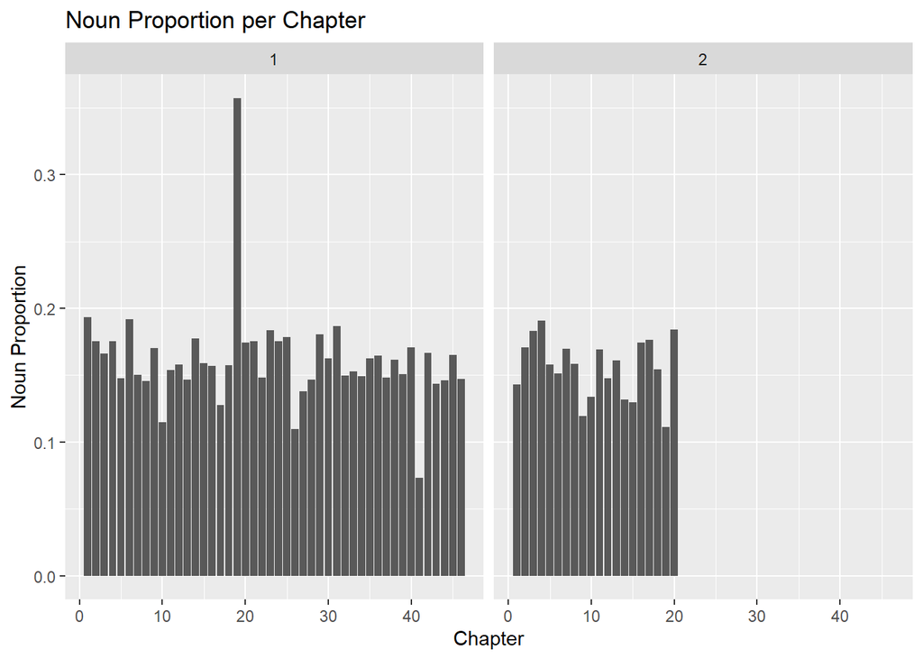

```r
df_pos |>
  ggplot(aes(x = chapter, y = nouns)) +
  geom_bar(stat = "identity") +
  facet_wrap(~ draft_num) +
  labs(x = "Chapter", y = "Noun Proportion", title = "Noun Proportion per Chapter")
```

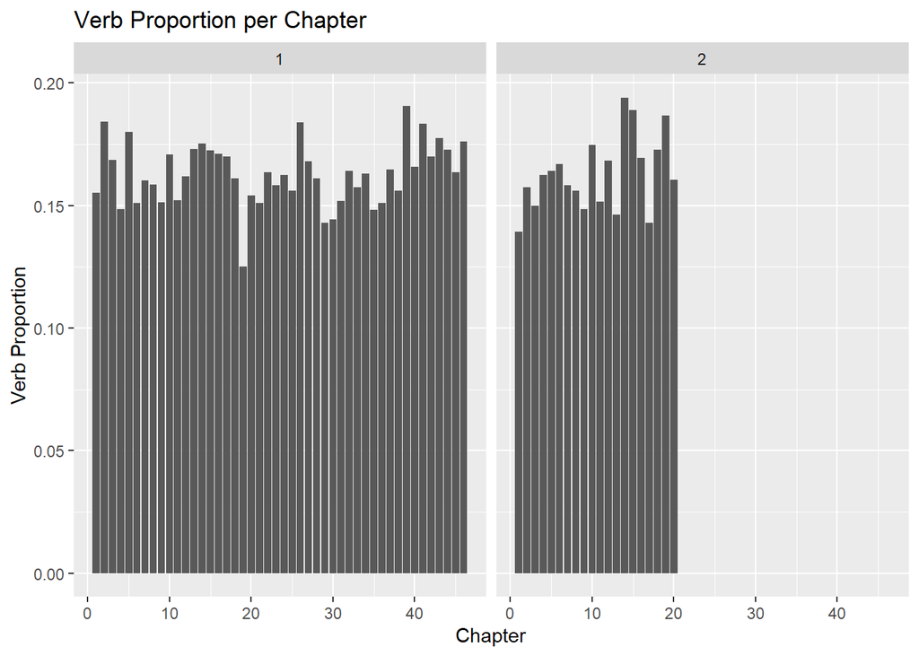

```r
df_pos |>
  ggplot(aes(x = chapter, y = verbs)) +
  geom_bar(stat = "identity") +
  facet_wrap(~ draft_num) +
  labs(x = "Chapter", y = "Verb Proportion", title = "Verb Proportion per Chapter")
```

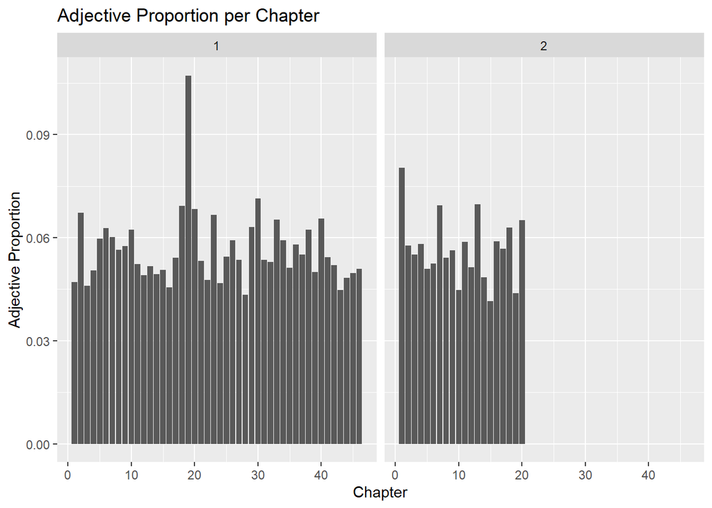

```r
df_pos |>
  ggplot(aes(x = chapter, y = adjectives)) +
  geom_bar(stat = "identity") +
  facet_wrap(~ draft_num) +
  labs(x = "Chapter", y = "Adjective Proportion", title = "Adjective Proportion per Chapter")
```

It doesn’t seem like there is an overall pattern in the proportion in which these parts of speech are used throughout the course of the two drafts.

To conclude our EDA, we can see how sentiment changes over chapter.

```r
df_sent <- df |>
  group_by(draft_num, chapter) |>
  summarise(sentiment = mean(sentiment))
df_sent
```

```
## # A tibble: 66 × 3
## # Groups:   draft_num [2]
##    draft_num chapter sentiment
##        <dbl>   <dbl>     <dbl>
##  1         1       1     0.286
##  2         1       2     1.12
##  3         1       3    -1.91
##  4         1       4     0.138
##  5         1       5    -3.38
##  6         1       6    -0.667
##  7         1       7     1.57
##  8         1       8     1
##  9         1       9     4.41
## 10         1      10    -8.25
## # ℹ 56 more rows
```

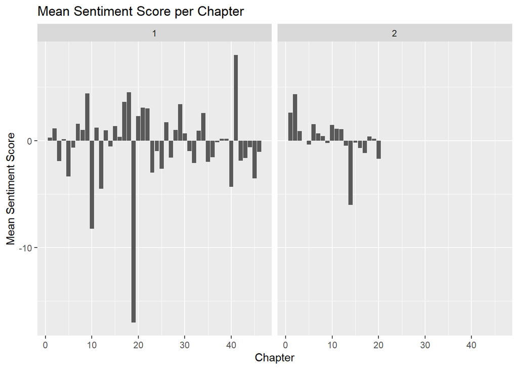

```r
df_sent |>
  ggplot(aes(x = chapter, y = sentiment)) +
  geom_bar(stat = "identity") +
  facet_wrap(~ draft_num) +
  labs(x = "Chapter", y = "Mean Sentiment Score", title = "Mean Sentiment Score per Chapter")
```

Perhaps draft 1 is more extreme, in one way or another?

Model Fitting

Let’s split the data, and then fit our models.

```r
library(tidymodels)
#0 is first draft, 1 is second draft
df <- df |>
  mutate(draft_num = draft_num - 1)

set.seed(12345)
df_split <- initial_split(df,
                              prop = 0.8)

df_train <- df_split |>
  training()

df_test <- df_split |>
  testing()
```

```r
df_train <- df_train |>
  mutate(draft_num = as.factor(draft_num)) |>
  dplyr::select(-c(text, text_id, chapter))

df_test <- df_test |>
  mutate(draft_num = as.factor(draft_num)) |>
  dplyr::select(-c(text, text_id, chapter))
```

Model 1: Logistic regression (with small penalty) on all factors.

```r
df_parsnip_1 <- logistic_reg(penalty = 0.01) |>
  set_mode("classification") |>
  set_engine("glmnet")

df_workflow_1 <- workflow() |>
  add_model(df_parsnip_1) |>
  add_formula(draft_num ~ .)

df_fit_1 <- df_workflow_1 |>
  fit(df_train)
```

Model 2: Logistic regression using top 5 principal components.

```r
df_parsnip_2 <- logistic_reg() |>
  set_mode("classification") |>
  set_engine("glm")

df_recipe_2 <- recipe(draft_num ~ .,
                       data = df_train)

df_recipe_2 <- df_recipe_2  |>
  step_normalize(all_numeric_predictors()) |>
  step_pca(all_numeric_predictors(),
           num_comp = 5) |>
  step_dummy(all_nominal_predictors())


df_workflow_2 <- workflow() |>
  add_model(df_parsnip_2) |>
  add_recipe(df_recipe_2)
```

```r
df_parsnip_3 <- nearest_neighbor() |>
  set_mode("classification") |>
  set_engine("kknn",
             neighbors = 3)

df_workflow_3 <- workflow() |>
  add_model(df_parsnip_3) |>
  add_formula(draft_num ~ .)
```

Model 4: Random forest.

```r
library(ranger)
df_parsnip_4 <- rand_forest() |>
  set_mode("classification") |>
  set_engine("ranger")

df_workflow_4 <- workflow() |>
  add_model(df_parsnip_4) |>
  add_formula(draft_num ~ .)
```

Model 5: Naive Bayes.

```r
library(klaR)
library(discrim)
df_parsnip_5 <- naive_Bayes() |>
  set_mode("classification") |>
  set_engine("klaR")

df_workflow_5 <- workflow() |>
  add_model(df_parsnip_5) |>
  add_formula(draft_num ~ .)
```

```r
workflow_names <- c("glm_lasso",
                 "glm_PCA",
                 "KNN",
                 "rf",
                 "naive_bayes")
```

```r
workflow_objects <- list(df_workflow_1,
                           df_workflow_2,
                          df_workflow_3,
                           df_workflow_4,
                           df_workflow_5)
```

```r
workflows_tbl <- tibble(work_names = workflow_names,
                        work_objects = workflow_objects)

workflows_tbl
```

```
## # A tibble: 5 × 2
##   work_names  work_objects
##   <chr>       <list>
## 1 glm_lasso   <workflow>
## 2 glm_PCA     <workflow>
## 3 KNN         <workflow>
## 4 rf          <workflow>
## 5 naive_bayes <workflow>
```

```r
set.seed(1)
workflows_tbl <- workflows_tbl |>
  rowwise() |>
  mutate(fits = list(fit(work_objects,
                         df_train)))
```

This is our table, with our objects (workflows) and our fits on the train data in separate columns.

```r
workflows_tbl
```

```
## # A tibble: 5 × 3
## # Rowwise:
##   work_names  work_objects fits
##   <chr>       <list>       <list>
## 1 glm_lasso   <workflow>   <workflow>
## 2 glm_PCA     <workflow>   <workflow>
## 3 KNN         <workflow>   <workflow>
## 4 rf          <workflow>   <workflow>
## 5 naive_bayes <workflow>   <workflow>
```

Model Assessment

Let’s take a look at what our models look like under the hood.

```r
df_parsnip_1 |>
  fit(draft_num ~ .,
      data = df_train) |>
  tidy()
```

```
## # A tibble: 28 × 3
##    term        estimate penalty
##    <chr>          <dbl>   <dbl>
##  1 (Intercept) -1.02       0.01
##  2 sentiment    0.00523    0.01
##  3 word_count   0.00194    0.01
##  4 ADJ          0          0.01
##  5 ADP          0          0.01
##  6 ADV         -6.11       0.01
##  7 AUX          0          0.01
##  8 CCONJ        0.00700    0.01
##  9 DET          1.31       0.01
## 10 NOUN         0          0.01
## # ℹ 18 more rows
```

```r
df_parsnip_2 |>
  fit(draft_num ~ .,
      data = df_train) |>
  tidy()
```

```
## # A tibble: 28 × 5
##    term         estimate std.error statistic p.value
##    <chr>           <dbl>     <dbl>     <dbl>   <dbl>
##  1 (Intercept)   1.57     11.2        0.141  0.888
##  2 sentiment     0.0137    0.0129     1.06   0.287
##  3 word_count    0.00396   0.00142    2.79   0.00520
##  4 ADJ          -5.34     11.5       -0.465  0.642
##  5 ADP          -1.47     11.4       -0.129  0.897
##  6 ADV         -11.8      11.5       -1.02   0.305
##  7 AUX          -4.52     11.4       -0.397  0.691
##  8 CCONJ        -0.231    11.9       -0.0195 0.984
##  9 DET           1.56     11.5        0.135  0.892
## 10 NOUN         -5.86     11.3       -0.518  0.604
## # ℹ 18 more rows
```

```r
df_workflow_3 |>
  fit(df_train) |>
  extract_fit_engine()
```

```
##
## Call:
## kknn::train.kknn(formula = ..y ~ ., data = data, ks = min_rows(5,     data, 5), neighbors = ~3)
##
## Type of response variable: nominal
## Minimal misclassification: 0.4306499
## Best kernel: optimal
## Best k: 5
```

```r
df_workflow_4 |>
  fit(df_train) |>
  extract_fit_engine()
```

```
## Ranger result
##
## Call:
##  ranger::ranger(x = maybe_data_frame(x), y = y, num.threads = 1,      verbose = FALSE, seed = sample.int(10^5, 1), probability = TRUE)
##
## Type:                             Probability estimation
## Number of trees:                  500
## Sample size:                      1031
## Number of independent variables:  27
## Mtry:                             5
## Target node size:                 10
## Variable importance mode:         none
## Splitrule:                        gini
## OOB prediction error (Brier s.):  0.2135599
```

```r
# Output is very long
#df_workflow_5 |>
#  fit(df_train) |>
#  extract_fit_engine()
```

And now see how well the models are fitting the data they were trained on.

```r
workflows_tbl <- workflows_tbl |>
  dplyr::select(work_names, work_objects, fits) |>
  mutate(pred_class_tr = list(predict(fits,
                                    df_train,
                                   type = "class"))) |>
  mutate(pred_prob_tr = list(predict(fits,
                                    df_train,
                                   type = "prob")))
```

```r
workflows_tbl <- workflows_tbl |>
  mutate(predictions_tr = list(bind_cols(pred_class_tr, pred_prob_tr))) |>
  dplyr::select(-c(pred_class_tr, pred_prob_tr))
```

```r
predictions_tr_tbl  <- workflows_tbl |>
  dplyr::select(work_names,
         predictions_tr) |>
  unnest(cols = c(predictions_tr)) |>
  cbind(draft_num = df_train |>
          pull(draft_num))

predictions_tr_tbl |>
  glimpse()
```

```
## Rows: 5,155
## Columns: 5
## $ work_names  <chr> "glm_lasso", "glm_lasso", "glm_lasso", "glm_lasso", "glm_l…
## $ .pred_class <fct> 0, 0, 0, 0, 0, 0, 0, 0, 0, 0, 0, 0, 0, 0, 0, 0, 0, 0, 0, 0…
## $ .pred_0     <dbl> 0.7571615, 0.6210679, 0.6976956, 0.7252265, 0.7393427, 0.7…
## $ .pred_1     <dbl> 0.2428385, 0.3789321, 0.3023044, 0.2747735, 0.2606573, 0.2…
## $ draft_num   <fct> 0, 0, 0, 0, 1, 0, 1, 0, 0, 0, 1, 0, 1, 1, 1, 1, 1, 1, 0, 1…
```

```r
predictions_tr_tbl |>
  filter(work_names == "glm_lasso") |>
  conf_mat(truth = draft_num, estimate = .pred_class)
```

```
##           Truth
## Prediction   0   1
##          0 619 297
##          1  45  70
```

```r
predictions_tr_tbl |>
  filter(work_names == "glm_PCA") |>
  conf_mat(truth = draft_num, estimate = .pred_class)
```

```
##           Truth
## Prediction   0   1
##          0 634 324
##          1  30  43
```

```r
predictions_tr_tbl |>
  filter(work_names == "KNN") |>
  conf_mat(truth = draft_num, estimate = .pred_class)
```

```
##           Truth
## Prediction   0   1
##          0 664   0
##          1   0 367
```

```r
predictions_tr_tbl |>
  filter(work_names == "rf") |>
  conf_mat(truth = draft_num, estimate = .pred_class)
```

```
##           Truth
## Prediction   0   1
##          0 664   5
##          1   0 362
```

```r
predictions_tr_tbl |>
  filter(work_names == "naive_bayes") |>
  conf_mat(truth = draft_num, estimate = .pred_class)
```

```
##           Truth
## Prediction   0   1
##          0 620 128
##          1  44 239
```

Now, we add the test predictions for the draft_num response variable.

```r
workflows_tbl <- workflows_tbl |>
  dplyr::select(work_names, work_objects, fits) |>
  mutate(pred_class = list(predict(fits,
                                    df_test,
                                   type = "class"))) |>
  mutate(pred_prob = list(predict(fits,
                                    df_test,
                                   type = "prob")))
```

```r
workflows_tbl <- workflows_tbl |>
  mutate(predictions = list(bind_cols(pred_class, pred_prob))) |>
  dplyr::select(-c(pred_class, pred_prob))
```

```r
predictions_tbl  <- workflows_tbl |>
  dplyr::select(work_names,
         predictions) |>
  unnest(cols = c(predictions)) |>
  cbind(draft_num = df_test |>
          pull(draft_num))

predictions_tbl |>
  glimpse()
```

```
## Rows: 1,290
## Columns: 5
## $ work_names  <chr> "glm_lasso", "glm_lasso", "glm_lasso", "glm_lasso", "glm_l…
## $ .pred_class <fct> 0, 0, 0, 0, 0, 0, 0, 0, 1, 0, 0, 0, 0, 0, 0, 0, 0, 0, 1, 0…
## $ .pred_0     <dbl> 0.6418777, 0.7554911, 0.5864747, 0.6498899, 0.7122158, 0.6…
## $ .pred_1     <dbl> 0.3581223, 0.2445089, 0.4135253, 0.3501101, 0.2877842, 0.3…
## $ draft_num   <fct> 0, 0, 0, 0, 0, 0, 0, 0, 0, 0, 0, 0, 0, 0, 0, 0, 0, 0, 0, 0…
```

Assessing uncertainty: Prediction results on Test Data

```r
predictions_tbl |>
  filter(work_names == "glm_lasso") |>
  conf_mat(truth = draft_num, estimate = .pred_class)
```

```
##           Truth
## Prediction   0   1
##          0 148  81
##          1   9  20
```

```r
predictions_tbl |>
  filter(work_names == "glm_PCA") |>
  conf_mat(truth = draft_num, estimate = .pred_class)
```

```
##           Truth
## Prediction   0   1
##          0 152  92
##          1   5   9
```

```r
predictions_tbl |>
  filter(work_names == "KNN") |>
  conf_mat(truth = draft_num, estimate = .pred_class)
```

```
##           Truth
## Prediction   0   1
##          0 108  59
##          1  49  42
```

```r
predictions_tbl |>
  filter(work_names == "rf") |>
  conf_mat(truth = draft_num, estimate = .pred_class)
```

```
##           Truth
## Prediction   0   1
##          0 139  74
##          1  18  27
```

```r
predictions_tbl |>
  filter(work_names == "naive_bayes") |>
  conf_mat(truth = draft_num, estimate = .pred_class)
```

```
##           Truth
## Prediction   0   1
##          0 123  73
##          1  34  28
```

It seems as though overall, the models are predicting too many zeroes– they think too many of the test data are from the first draft. This issue is quite apparent with the GLM models, which predict less than 30 of the documents in the test set to have been from the second draft. Let’s take a look at some other metrics, starting with F1.

```r
predictions_tbl |>
  filter(work_names == "glm_lasso") |>
  f_meas(truth = draft_num,
         estimate =.pred_class)
```

```
## # A tibble: 1 × 3
##   .metric .estimator .estimate
##   <chr>   <chr>          <dbl>
## 1 f_meas  binary         0.767
```

```r
predictions_tbl |>
  filter(work_names == "glm_PCA") |>
  f_meas(truth = draft_num,
         estimate =.pred_class)
```

```
## # A tibble: 1 × 3
##   .metric .estimator .estimate
##   <chr>   <chr>          <dbl>
## 1 f_meas  binary         0.758
```

```r
predictions_tbl |>
  filter(work_names == "KNN") |>
  f_meas(truth = draft_num,
         estimate =.pred_class)
```

```
## # A tibble: 1 × 3
##   .metric .estimator .estimate
##   <chr>   <chr>          <dbl>
## 1 f_meas  binary         0.667
```

```r
predictions_tbl |>
  filter(work_names == "rf") |>
  f_meas(truth = draft_num,
         estimate =.pred_class)
```

```
## # A tibble: 1 × 3
##   .metric .estimator .estimate
##   <chr>   <chr>          <dbl>
## 1 f_meas  binary         0.751
```

```r
predictions_tbl |>
  filter(work_names == "naive_bayes") |>
  f_meas(truth = draft_num,
         estimate =.pred_class)
```

```
## # A tibble: 1 × 3
##   .metric .estimator .estimate
##   <chr>   <chr>          <dbl>
## 1 f_meas  binary         0.697
```

It looks as though by this metric, GLM-lasso does the best by a small margin.

```r
classification_metrics <- metric_set(accuracy, mcc, f_meas)

df_results <- predictions_tbl |>
  group_by(work_names) |>
    classification_metrics(truth = draft_num,
                         estimate =.pred_class)
```

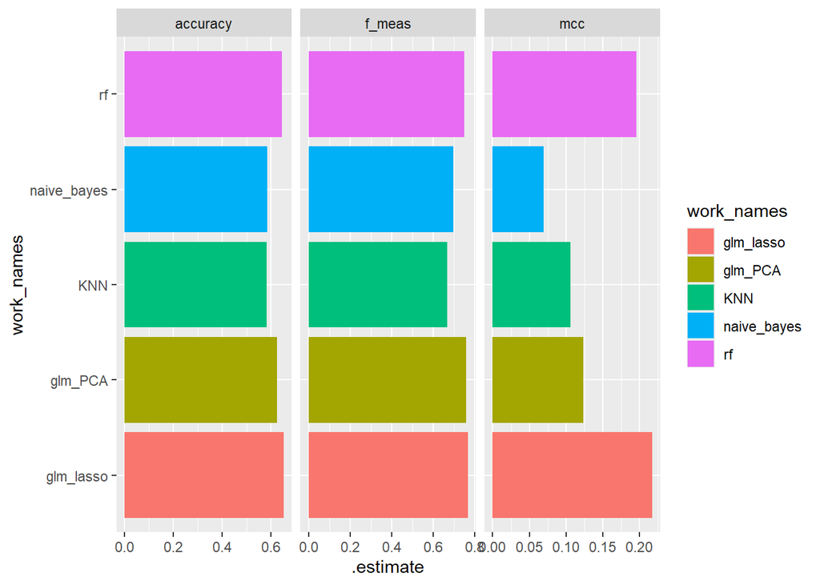

```r
df_results |>
  ggplot(aes(y = work_names,
             x = .estimate,
             fill = work_names)) +
  geom_col() +
  facet_wrap(~.metric, scales = "free_x")
```

Taking mcc into account, along with F1 and accuracy, our two best models are the glm_lasso and the random forest. We can also compare the ROC curves for the five models:

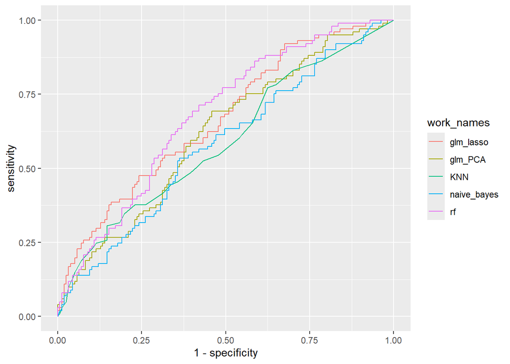

```r
roc_all <- predictions_tbl |>
  group_by(work_names) |>
  roc_curve(truth = draft_num,
            .pred_1,
            event_level = "second")

roc_all |>
  ggplot(aes(x = 1- specificity,
             y = sensitivity,
             color = work_names)) +
  geom_path()
```

Though none of them are necessarily great, the pink line (random forest) looks to be best.

DISCUSSION: It seems as though, based on the confusion matrices for rf and knn in the train and test data, there was some overfitting happening. Perhaps this was to be expected– there were a lot of columns that were extracted and not a lot of rows, all things considered. Perhaps using PCA to cut the columns down would have helped some.

Let’s test that theory by cutting down our columns to 3 with PCA, then fitting an rf model on the result.

```r
df_new <- df |>
  mutate(draft_num = as.factor(draft_num)) |>
  dplyr::select(-c(text, text_id, chapter, draft_num))

pca_df <- prcomp(df_new, scale. = TRUE, rank. = 3)
```

```r
new <- as.data.frame(pca_df$x)

new <- new |>
  mutate(draft_num = as.factor(df$draft_num))
```

```r
set.seed(12345)
new_split <- initial_split(new,
                              prop = 0.8)

new_train <- new_split |>
  training()

new_test <- new_split |>
  testing()
```

```r
new_parsnip_rf <- rand_forest() |>
  set_mode("classification") |>
  set_engine("ranger")

new_workflow_rf <- workflow() |>
  add_model(new_parsnip_rf) |>
  add_formula(draft_num ~ .)
```

```r
new_workflow_rf |>
  fit(new_train) |>
  extract_fit_engine()
```

```
## Ranger result
##
## Call:
##  ranger::ranger(x = maybe_data_frame(x), y = y, num.threads = 1,      verbose = FALSE, seed = sample.int(10^5, 1), probability = TRUE)
##
## Type:                             Probability estimation
## Number of trees:                  500
## Sample size:                      1031
## Number of independent variables:  3
## Mtry:                             1
## Target node size:                 10
## Variable importance mode:         none
## Splitrule:                        gini
## OOB prediction error (Brier s.):  0.2345257
```

```r
predictions <- new_workflow_rf |>
  fit(new_train) |>
  predict(new_train) |>
  pull(.pred_class)
```

```r
table(Actual = new_train$draft_num, Predicted = predictions)
```

```
##       Predicted
## Actual   0   1
##      0 660   4
##      1  30 337
```

It still does pretty well on the train data! Let’s try using the test now:

```r
predictions <- new_workflow_rf |>
  fit(new_train) |>
  predict(new_test) |>
  pull(.pred_class)
```

```r
table(Actual = new_test$draft_num, Predicted = predictions)
```

```
##       Predicted
## Actual   0   1
##      0 130  27
##      1  79  22
```

Also, the most challenging part of this analysis by far was the feature extraction. It was computationally a very long process, as pulling out parts of speech took some time, and the topic modeling was not straightforward as well. I had to use lots of regular expressions and pivoting of columns to end up making it all work.

Used: List columns in dataframes, regular expressions to filter data, principal component analysis, topic modeling, word cloud representation of data